# Compare Gauge Maxima over all Sources

This notebook illustrates one approach to comparing the 36 [Cascadia CoPes Hub Ground Motions and Tsunami Sources](https://depts.washington.edu/ptha/CHTuser/docs/seismic-and-tsunami-sources/) at one of the Lagoon Creek gauge locations.

The maximum water depth is plotted for each of the 36 events, both in the usual alphabetical order of event names and also after ordering from smallest to largest values.

The sources have been assigned weights in the logic tree that is shown and discussed in the webpage linked above. These 36 weights sum to 1, and might be viewed as conditional probabilities, given that a single major CSZ earthquake occurs. These weights can be used to determine, for example, the median inundation depth over all the events, or the depth corresponding to any quantile.

Note that this is not a full Probabilistic Tsunami Hazard Assessment (PTHA), since it is based on the assumption that exactly one CSZ earthquake has occurred, and does not take into account the annual probability that this happens, or the possibility that more than one earthquake could occur in a given time period. The notebook HazardCurveDemo discusses how PTHA might be performed, although we note that these particular sources were not originally designed for PTHA purposes.

However, the analysis in this notebook might be useful to those studying the paleoseismic evidence, for example, where the question is more focused on the chance that a past CSZ tsunami could have reached a particular point, rather than hazard mitigation.

```python
%matplotlib inline
```

```python
from pylab import *
from clawpack.pyclaw.gauges import GaugeSolution
```

## Specify the set of events and the logic tree weight of each

We use the weights from the logic tree shown in [Cascadia CoPes Hub Ground Motions and Tsunami Sources](https://depts.washington.edu/ptha/CHTuser/docs/seismic-and-tsunami-sources/).

```python
depths = ['D','M','S']

# buried_locking events:
all_events = [f'BL10{depth}' for depth in depths] \
           + [f'BL13{depth}' for depth in depths] \
           + [f'BL16{depth}' for depth in depths] \

# add random events:
all_events += [e.replace('L','R') for e in all_events]

# add Frontal Thrust events:
all_events += [e.replace('B','F') for e in all_events]

all_events.sort()
print(f'all_events contains {len(all_events)} events')
```

```
all_events contains 36 events
```

```python
print('Event weights from logic tree:')

event_weights = {}

for event in all_events:
    w = 1/3 * 0.5
    if 'B' in event:
        w *= 0.75
    else:
        w *= 0.25
    if 'D' in event:
        w *= 0.3
    elif 'M' in event:
        w *= 0.5
    else:
        w*=0.2
    event_weights[event] = w
    print(f'    {event}:  {w:.5f}')

weights = array([event_weights[e] for e in all_events])
print(f'The weights sum to {weights.sum():.3f}')
```

```
Event weights from logic tree:
    BL10D:  0.03750
    BL10M:  0.06250
    BL10S:  0.02500
    BL13D:  0.03750
    BL13M:  0.06250
    BL13S:  0.02500
    BL16D:  0.03750
    BL16M:  0.06250
    BL16S:  0.02500
    BR10D:  0.03750
    BR10M:  0.06250
    BR10S:  0.02500
    BR13D:  0.03750
    BR13M:  0.06250
    BR13S:  0.02500
    BR16D:  0.03750
    BR16M:  0.06250
    BR16S:  0.02500
    FL10D:  0.01250
    FL10M:  0.02083
    FL10S:  0.00833
    FL13D:  0.01250
    FL13M:  0.02083
    FL13S:  0.00833
    FL16D:  0.01250
    FL16M:  0.02083
    FL16S:  0.00833
    FR10D:  0.01250
    FR10M:  0.02083
    FR10S:  0.00833
    FR13D:  0.01250
    FR13M:  0.02083
    FR13S:  0.00833
    FR16D:  0.01250
    FR16M:  0.02083
    FR16S:  0.00833
The weights sum to 1.000
```

## Load the gauge data for all events

This assumes the script `make_gauge_upload.py` has already been run to make `.txt` files for each event/gauge combination in the format used by the Code Verification Platform.

Set `gaugeno` to 1, 2, or 3 for one of the onshore gauges. Note that at offshore gauges a clearer comparison might be to plot the maximum sea surface elevation rather than water depth.

```python
#gauges_dir = 'geoclaw_gauges_to_upload'
gauges_dir = 'geoclaw_gauges_all_events'
gaugeno = 2
hmax = []
events = array(all_events)

print(f'Maximum water depth at Gauge {gaugeno} for each event:')

for event in events:
    fname_gauge = f'{gauges_dir}/{event}_gauge{gaugeno:05d}.txt'
    #print(fname_gauge)
    gauge_data = loadtxt(fname_gauge, comments='#', skiprows=15)
    h = gauge_data[:,1]
    hmax_k = h.max()
    print(f'{event}: {hmax_k:.3f}')
    hmax.append(hmax_k)

hmax = array(hmax)
```

```
Maximum water depth at Gauge 2 for each event:
BL10D: 10.162
BL10M: 13.501
BL10S: 3.581
BL13D: 3.854
BL13M: 8.365
BL13S: 8.745
BL16D: 6.998
BL16M: 5.155
BL16S: 3.731
BR10D: 12.482
BR10M: 6.072
BR10S: 12.225
BR13D: 0.289
BR13M: 5.406
BR13S: 5.431
BR16D: 0.000
BR16M: 0.000
BR16S: 0.657
FL10D: 28.884
FL10M: 14.991
FL10S: 3.823
FL13D: 0.553
FL13M: 3.296
FL13S: 13.467
FL16D: 9.980
FL16M: 2.462
FL16S: 4.882
FR10D: 10.877
FR10M: 6.129
FR10S: 10.613
FR13D: 9.018
FR13M: 1.584
FR13S: 3.311
FR16D: 4.699
FR16M: 2.119
FR16S: 3.119
```

## Plot these values for each event

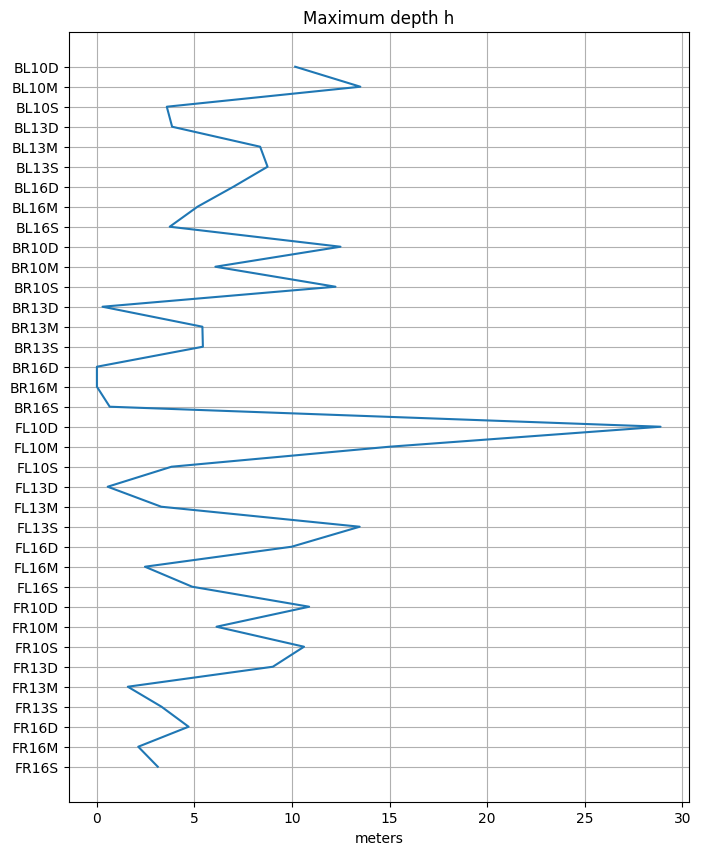

```python
figure(figsize=(8,10))
ievents = range(len(events))
plot(hmax, ievents)
yticks(ievents, events)
gca().invert_yaxis() # so first event is on top
grid(True)
xlabel('meters')
title(f'Maximum depth h');
```

## Sort from smallest to largest hmax

This gives a nicer plot and is needed for computing quantiles.

```python
ind = argsort(hmax)
hmax_sort = hmax[ind]
events_sort = events[ind]
weights_sort = weights[ind]
```

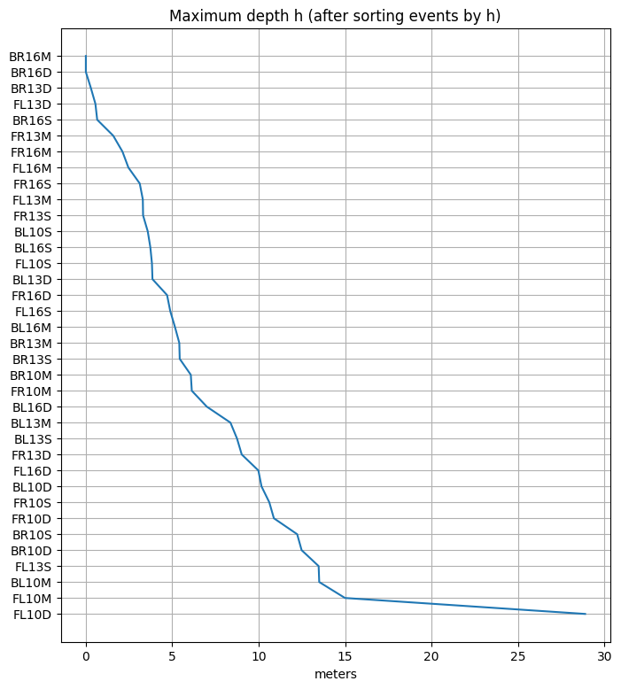

```python
figure(figsize=(8,9))
ievents = range(len(events)-1,-1,-1)
plot(hmax_sort, ievents)
yticks(ievents, events_sort);
grid(True)
xlabel('meters')
title(f'Maximum depth h (after sorting events by h)');
```

## Plot as a bar chart with an indication of weights

The width of each bar in the bar chart will be proportional to the weight of that event from the logic tree.

```
Created  LagoonCreek_Gauge00002_depth_bars.png
```

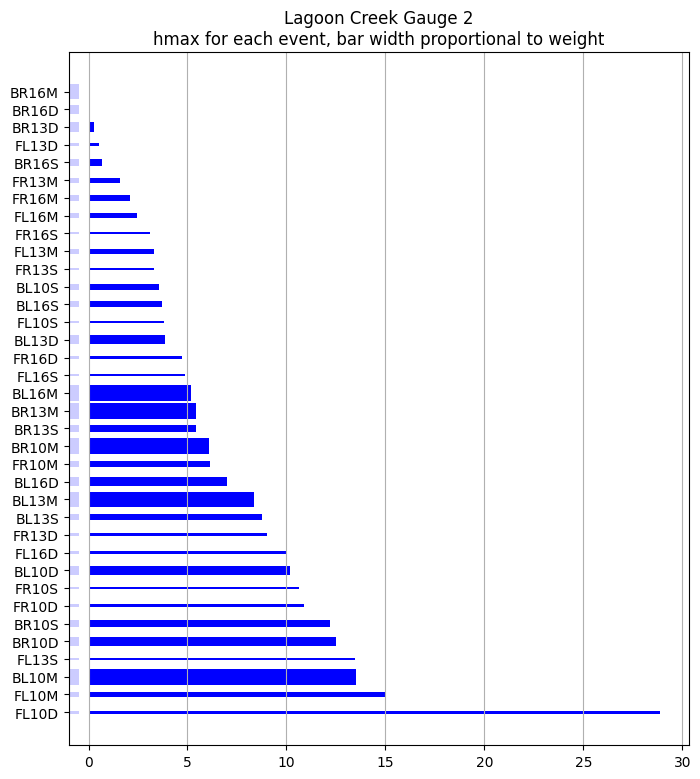

```python
heights_sort = 14 * weights_sort  # scale to get reasonable bar widths

fig,ax = subplots(figsize=(8,9))

# plot short bars to left of 0 to show width also for events with hmax=0:
left_offset = -0.5
ax.barh(events_sort, left_offset, left=left_offset,
        height=heights_sort, color='b', alpha=0.2)
ax.set_xlim(2*left_offset, 1.05*hmax_sort.max())

ax.barh(events_sort, hmax_sort,
        height=heights_sort, color='b')
ax.invert_yaxis()
ax.grid(axis='x')
ax.set_title(f'Lagoon Creek Gauge {gaugeno}\n'
             'hmax for each event, bar width proportional to weight');
fname = f'LagoonCreek_Gauge{gaugeno:05d}_depth_bars.png'
savefig(fname)
print('Created ',fname)
```

## Compute cumulative weights and quantiles:

```python
wcum = zeros(len(hmax_sort)+1)  # with one extra 0 to start sum at end, and for plotting

for k in range(len(events_sort)-1,-1,-1):
    wcum[k] = wcum[k+1] + weights_sort[k]

# add one more data point with h > hmax.max() and probability 0, for tail of step function:
hmax_step = hstack((hmax_sort, hmax_sort.max()+1))
```

```python
quantiles = [50,80]
wq = {}
hq = {}
events_wq = {}
for q in quantiles:
    wq[q] = 1 - 0.01*q
    k = where(wcum >= wq[q])[0].max()
    print(f'{len(wcum) - k} events contribute to the {q}% quantile depth:')
    events_wq[q] = events_sort[k-1:]
    print(events_wq[q])
    hq[q] = hmax_sort[k]
    print(f'with {q}% quantile inundation depth = {hq[q]:.2f} meters\n')
```

```
19 events contribute to the 50% quantile depth:
['BL16M' 'BR13M' 'BR13S' 'BR10M' 'FR10M' 'BL16D' 'BL13M' 'BL13S' 'FR13D'
 'FL16D' 'BL10D' 'FR10S' 'FR10D' 'BR10S' 'BR10D' 'FL13S' 'BL10M' 'FL10M'
 'FL10D']
with 50% quantile inundation depth = 5.41 meters

10 events contribute to the 80% quantile depth:
['FL16D' 'BL10D' 'FR10S' 'FR10D' 'BR10S' 'BR10D' 'FL13S' 'BL10M' 'FL10M'
 'FL10D']
with 80% quantile inundation depth = 10.16 meters
```

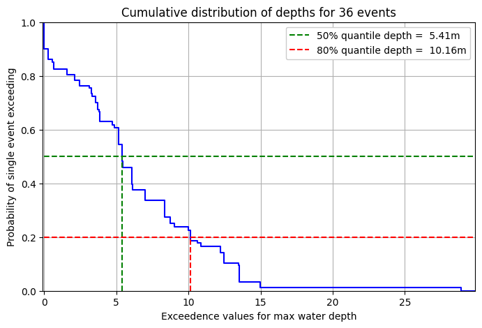

```python
fig,ax = subplots(figsize=(8,5))
step(hmax_step, wcum, 'b', where='pre')
xlim(-0.1, hmax_step.max())
ylim(0, 1)
grid(True)
ax.set_xlabel('Exceedence values for max water depth')
ax.set_ylabel('Probability of single event exceeding')

# plot dashed lines at specific quantiles:
qcolors = ['g','r','m']
for k,q in enumerate(quantiles):
    label = f'{q}% quantile depth = {hq[q]: .2f}m'
    ax.plot(hmax_step, wq[q]*ones(hmax_step.shape), '--', color=qcolors[k], label=label)

    # plot vertical dashed lines showing depths:
    ax.plot([hq[q],hq[q]], [0,wq[q]], '--', color=qcolors[k])
    ax.legend(loc='upper right', framealpha=1, fontsize=10)

title(f'Cumulative distribution of depths for {len(events)} events');
```

## Summary

The plot above shows the distribution of maximum inundation depth at one particular gauge location. The probability on the vertical axis goes from 0 to 1 since it is based on the assumption that a single CSZ event happens, chosen from the 36 CoPes Hub sources with probability corresponding to its weight in the logic tree, and these weights sum to 1. The plot is a step function with steps corresponding to each event, and the vertical jump at each step is the weight of that event. It is in fact simply the upper envelope of the bar chart shown earlier.

This curve is similar to a *hazard curve* that might come out of a PTHA analysis, but that curve would show the annual proability of exceeding each water depth. It is more complicated to compute, since one must also allow for the possibility that no event occurs or more than one event occurs in a given year. One must also make assumptions on the annual probability of any major CSZ event occuring and about the probability distribution of a major event.

For more discussion and an illustration of how a hazard curve could be computed, see HazardCurveDemo, rendered from the notebook `geoclaw_multirun/HazardCurveDemo.ipynb` in the repository.